# Finales Dokument Semesterprojekt Wildschweinschreck von Bettina Putzi

Bettina Putzi

02.07.2021

**Einzelarbeit gemäss Abmachung mit Patrick Laube**

## Einleitung

Für die Untersuchung zur Wirkung des Wildschweinschrecks wurde ein Gebiet im Kanton Bern namens Fanel untersucht. Dort wurden über mehrere Jahre Wildschweine mit GPS-Halsbändern, die im Grundintervall alle 15 Minuten einen Positionspunkt lieferten, getrackt. Im Gebiet dieser Wildschweine wurden Wildschweinschrecks installiert und über unterschiedliche Zeiträume zur Wildschweinvergrähmung genutzt (Wassmer, 2017).

Die vorliegende Studie möchte den Einfluss des Wildschweinschrecks untersuchen. Dafür werden unterschiedliche Zeitperioden genauer analysiert. Dies sind

- Δt1: Zeitspanne 5 Stunden und 2 Tage oder 7 Tage vor dem ersten Alarm eines Wildschweinschrecks
- Δt2: Zeitspanne 5 Stunden und 2 Tage oder 7 Tage nach dem ersten Alarm eines Wildschweinschrecks (bzw. in der Anfangsperiode einer Wildschweinschreck-Testperiode)

Bei einer klaren Beeinflussung durch den Wildschweinschreck werden zusätzlich noch folgende Zeitspannen näher untersucht:

- Δt3: Zeitspanne 5 Stunden und 2 Tage oder 7 Tage vor dem letzten Alarm eines Wildschweinschrecks (bzw. in der Endperiode einer Wildschweinschreck-Testperiode)
- Δt4: Zeitspanne 5 Stunden und 2 Tage oder 7 Tage nach dem letzten Alarm eines Wildschweinschrecks

Nachfolgend ist illustriert, welche Perioden analysiert werden.

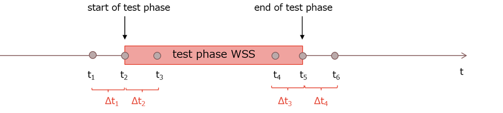

Zeitpunkte und Zeitperioden der Untersuchung

Die Studie unterteilt sich in drei Haupt-Teile.

1. Anhand einer Voranalyse werden die Daten von mehreren Wildschweinen und Wildschweinschrecks betrachtet, umgeformt, und reduziert. So bleiben reduzierte Datensets zurück, mit denen die eingangs erwähnte Analyse durchgeführt werden kann (die Datensätze werden mit dem Vermerk "_relevant" bezeichnet).
2. Die erste Forschungsfrage beschäftigt sich mit den Wildschwein-Verhalten (räumlich zeitliche Bewegugsbahnen) **vor** (Δt1), **während** (Δt2, Δt3) und allenfalls **nach** (Δt4) der Wildschweinschreck-Testperiode. Insbesondere der Effektbereich ist von interesse. Es werden sogenannte **second Order Effects** untersucht (Gudmundsson et al., 2012).
3. Die zweite Forschungsfrage beschäftigt sich mit dem Verhalten der Wildschweine in Bezug auf die Umgebung. Es wird untersucht, ob es eine Verschiebung der bevorzugten Umgebung gibt. Dies bezeichnet sogenannte **fist Order Effects** (Gudmundsson et al., 2012).

Der Hauptteil 1 wird im nachfolgenden Kapitel dokumentiert:

## Teil 1: Übersicht und Dataset-Reduktion

Zuerst wird eine explorative Datenanalyse durchgeführt, um zu entscheiden, welche Tiere und welche Wildschweinschrecks für die Analysen einbezogen werden sollten. Es sollten Tiere sein, die sich **während der Laufzeit** der Wildschweinschrecks in deren Nähe befanden. Dabei sollten im Datensatz **Positionsdaten der Wildschweine vor, während und nach der Laufzeit** der Wildschweinschrecks vorhanden sein. Einige Eckpunkte daraus werden nachfolgend kurz beschrieben:

#### 1. Übersicht der getrackten 19 Wildschweine im Originaldatensatz für die Definition des maximal zu untersuchenden Zeitintervalls

Minimum-Datum: 2014-05-28, Maximum-Datum: 2016-10-18

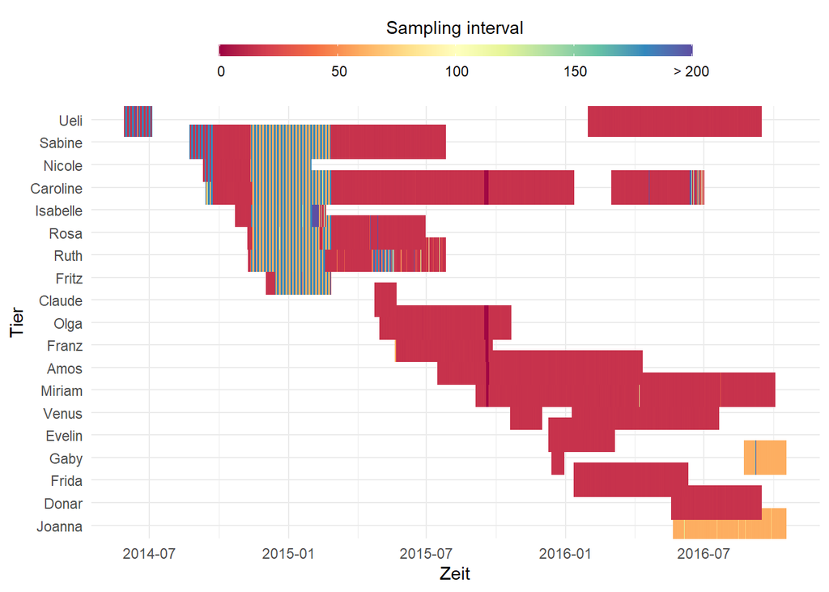

#### 2. Geografische Zusammenhänge zwischen den Wildschweinen und den Wildschweinschrecks

Visualisierung der Aufenthaltsgebiete mit allen vorhandenen Positionspunkte pro Individuum, um die maximale räumliche Ausdehnung darstellen zu können. Die Convex-Hulls stellen das Einflussgebiet der verschiedenen Wildschweine dar und die Punkte die Wildschweinschrecks.

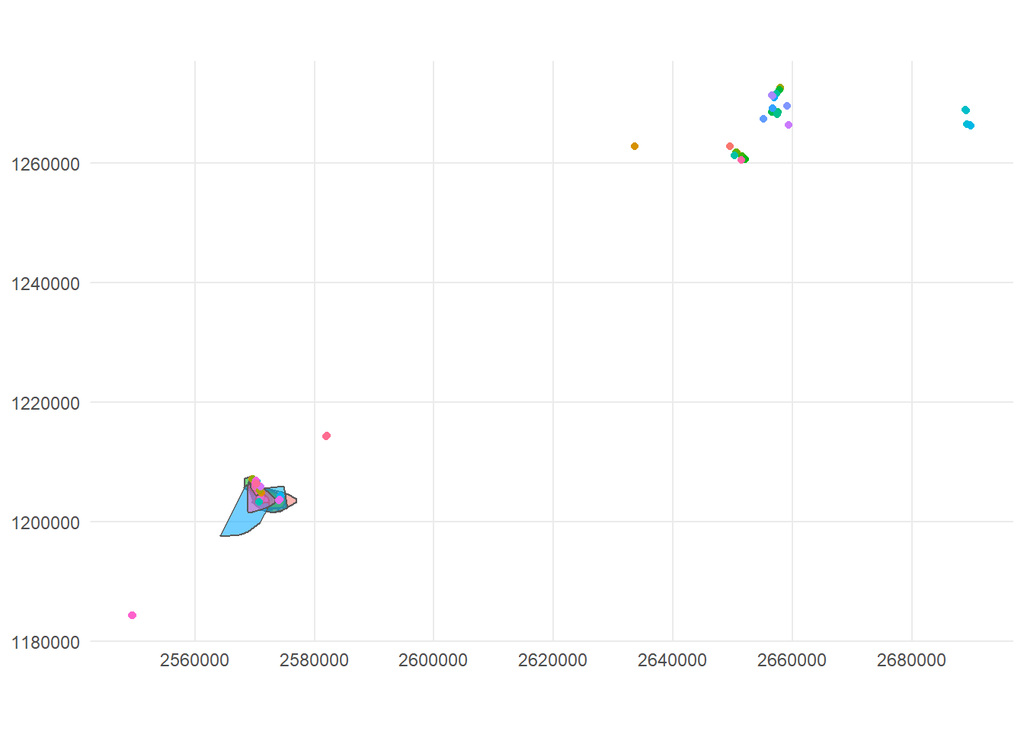

Diejenigen Wildschweinschrecks, die nicht in den Convex-Hulls der Wildschweine sind, werden herausgefiltert. In dessen Nähe haben sich die Wildschweine nie aufgehalten. Dies wird explorativ gemäss dem letzten Plot gemacht, indem die Koordinaten eingegrenzt werden (X <= 2580000 & X>2560000 & Y <= 1210000 & Y > 119000).

**Feststellung**: Viele Schrecks liegen ausserhalb des Aufenthaltsgebietes der Wildschweine.

#### 3. Zeitlich und geografisch relevante Wildschweinschrecks in Abhängigkeit von den Wildschweindaten

All diejenigen Schreckdaten werden gelöscht, die sich nicht mit den Zeitperioden der Wildschweindaten überschneiden. Das sind die Schrecks die vor und nach dem Tracking der Wildschweine laufen (Aus Task 1). So entsteht der Datensatz, der nur noch die für diese Studie relevanten Wildschweinschrecks enthält.

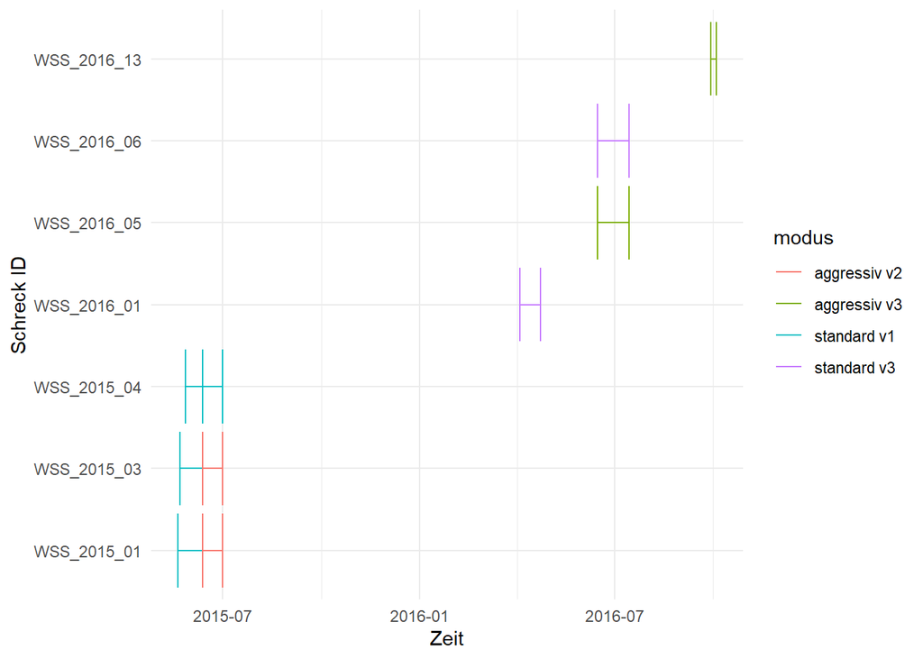

#### 4. Wildschweine, deren Zeitintervalle sich mit denjenigen der relevanten Wildschweinschrecks überlappen

Die Wildschweine mit Trackingdaten vor, im Verlauf und nach der Schreck-Laufdauer werden herausgefiltert. So entsteht der neue Wildschweindatensatz, der nur noch relevante Wildschweine enthält.

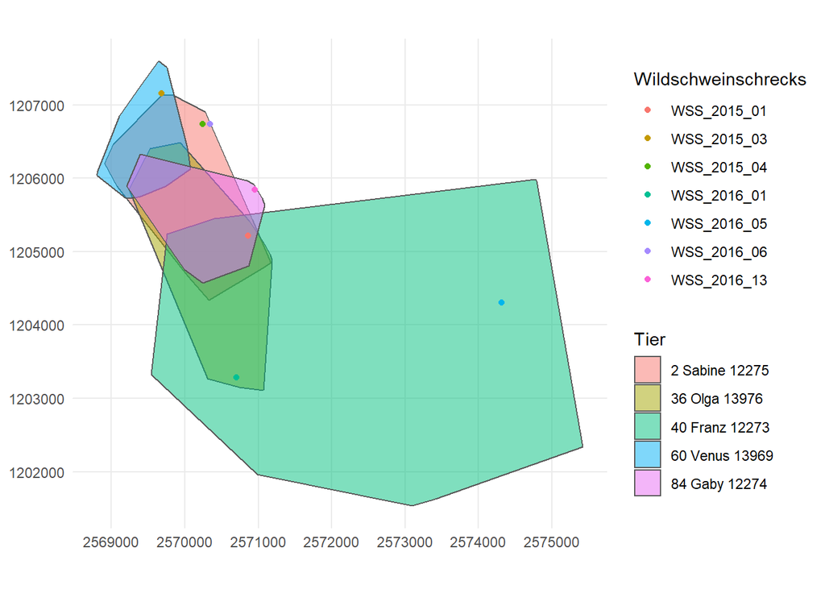

#### Zwischenschritt: Farbcodes zu den Wildschweinen zuordnen

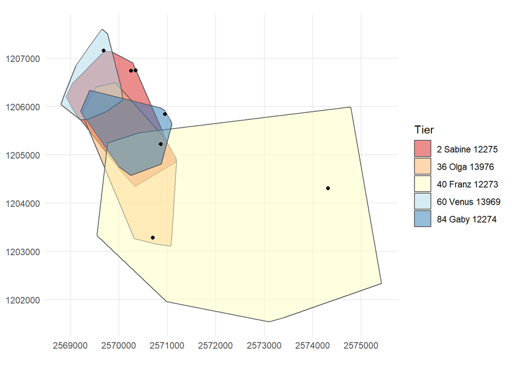

#### 5. Die Überlappungen der Wildschweine mit den einzelnen Wildschweinschrecks

Da das Wildschweinverhalten vor und nach der Testphase der Wildschweinschrecks untersucht werden soll, muss analysiert werden, welche Wildschwein-Messungen sich mit welchen Wildschweinschreck-Testphasen überlappen und wie lange eine Überlappung vorliegt.

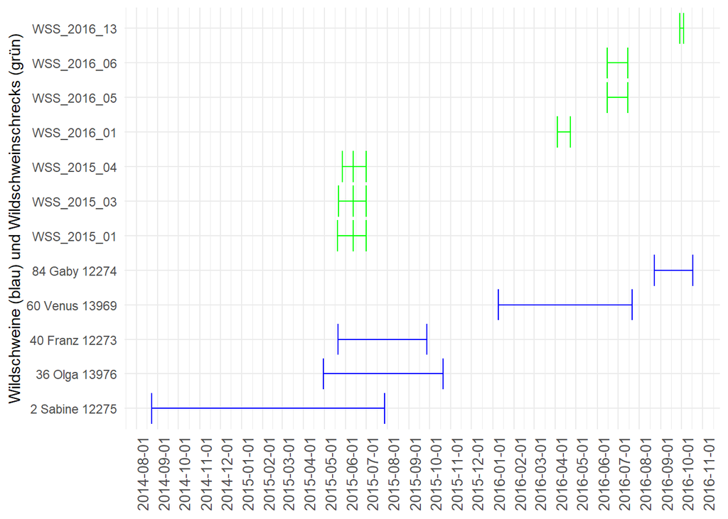

### Fazit Voranalyse

Als Zwischenfazit nach der explorativen Analyse konnte folgendes herausgefunden werden:

- Gaby wäre für WSS_2016_13 geeignet, wobei dieser Wildschweinschreck mit 5 Tagen sehr kurz in Betrieb ist (wird deshalb von der weiteren Untersuchung ausgeschlossen)
- Sabine, Olga und Franz eignen sich alle drei für die drei Wildschweinschrecks “WSS_2015_01”, “WSS_2015_03” und “WSS_2015_04”
- Venus ist für die Analyse von «WSS_2016_01», «WSS_2016_05» und «WSS_2016_06» geeignet
- Die initial grossen Datensätze mit vielen irrelevanten Schweinen und Wildschweinschrecks konnten stark reduziert werden.
- Die Zeitperioden der verbleibenden Wildschweine überlappen diejenigen der Wildschweinschrecks vor und nach der Testphase .

## Teil 2: Forschungsfrage 1, Second Order Effects

> Wie kann der Effektbereich der Wildschwein-Schrecks von den räumlich-zeitlichen Laufbahnen der Wildschweine hergeleitet werden?

Eine Studie der ZHAW erklärt folgendes: "Die Wahrscheinlichkeit, dass der nächtliche Immissionsgrenzwert von 55 dB(A) durch die Geräusche des Wildschweinschrecks bei Einstellung der maximalen Lautstärke überschritten wird, liegt bei den Distanzen von 2m, 10m und 50m bei 100%. Bei 100m und 200m liegt diese Wahrscheinlichkeit immer noch bei über 90%, hingegen bei 500m nur noch bei 20%. Bei 1000m Distanz liegt die Wahrscheinlichkeit der Überschreitung der gesetzlichen Immissionsgrenzwerte bei 0% und ab 1500m sind keine Geräusche mehr messbar.» (Suter et al., 2018, 23f.). Entsprechend wird hier als ersten Anhaltspunkt angenommen, dass mindestens bei 200 Meter ein Einfluss des Schrecks auf die Wildschweine vermutbar wäre.

Als datenbasierte mögliche Messgrösse könnte Beispielsweise der Abstand zum Schrecks nach Ertönen vor und nach des ersten Signaltons zu Zeitpunkt t2 analysiert werden. Dazu muss aber zuerst untersucht werden, welche Wildschweine sich denn in der Nähe welches Schrecks aufhalten. Hierfür wird die Minimaldistanz zu den in der explorativen Analyse definierten relevanten Schrecks und Wildschweinen analysiert.

Die folgende Tabelle stellt die Minimaldistanzen zum Wildschwienschreck pro Wildschwein dar. Unter der vorher getroffenen Annahme von 200 Meter Einflussbereich, würde mindestens Sabine von drei Wildschwieinschrecks beeinflusst werden, sowie Olga und Franz von je einem.

| WSS | Franz | Sabine | Olga | Venus |
| --- | --- | --- | --- | --- |
| 2015_01 | 198.9037504553 | 10.2749708832912 | 8.18574014879988 | NA |
| 2015_03 | 1849.82455464483 | 25.4416838052553 | 708.188424673715 | NA |
| 2015_04 | 1295.07480541856 | 42.8559962143329 | 401.077429234862 | NA |
| 2016_01 | NA | NA | NA | 2781.51523001407 |
| 2016_05 | NA | NA | NA | 4612.28573255964 |
| 2016_06 | NA | NA | NA | 448.121050062242 |

Sabine, Franz und Olga werden entsprechend näher untersucht. Dazu werden die Wege der Schweine für unterschiedliche Zeitperioden vor ertönen des ersten Schrecks nach Ertönen des ersten Schrecks abgebildet. Diese Zeipterioden (Δt1 und Δt2) werden auf **fünf Stunden** und **zwei Tage** festgelegt. Auch die Distanz zum Zeitpunkt des ersten Schrecksignals (t2) wird berücksichtigt.

### Untersuchung Sabine

Die folgende Grafik untersucht das Verhalten von Sabine in Abhängigkeit des Wildschweinschrecks *2015_04*, jeweils fünf Stunden und 2 Tag vor und nach dem ersten Schrecksignal.

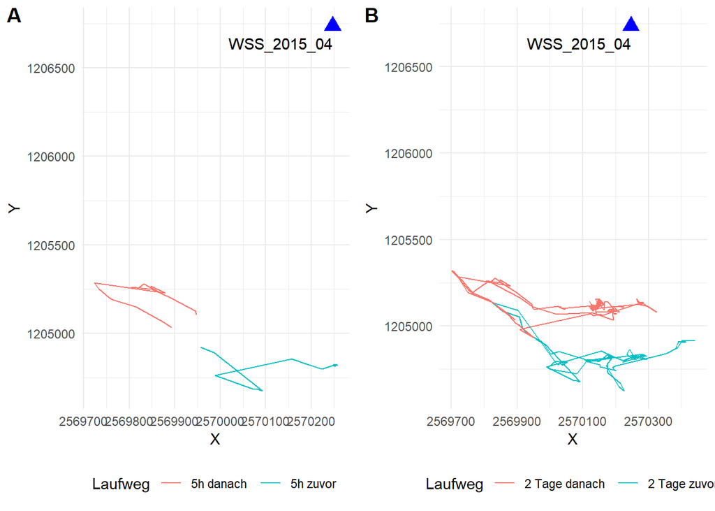

Der Wildschweinschreck *2015_04* scheint keinen Einfluss auf das Verhalten von Sabine zu haben. Die Distanz von Sabine zum Wildschweinschreck zum Zeitpunkt des ersten Ertönens (t2) zeigt eine bereits sehr lange Distanz von 1740 Meter. Bei dieser Distanz lässt sich das Wildschwein wohl nicht stören und geht sogar noch etwas näher ran.

```r
Sabine_t2_t3_04_2d$distance_2015_04[1]
```

```
## [1] 1740.099
```

Es wird nun ein weiterer Wildschweinschreck untersucht, der Einfluss auf Sabine haben könnte. Dies ist laut Tabelle Wildschweinschreck *2015_01*.

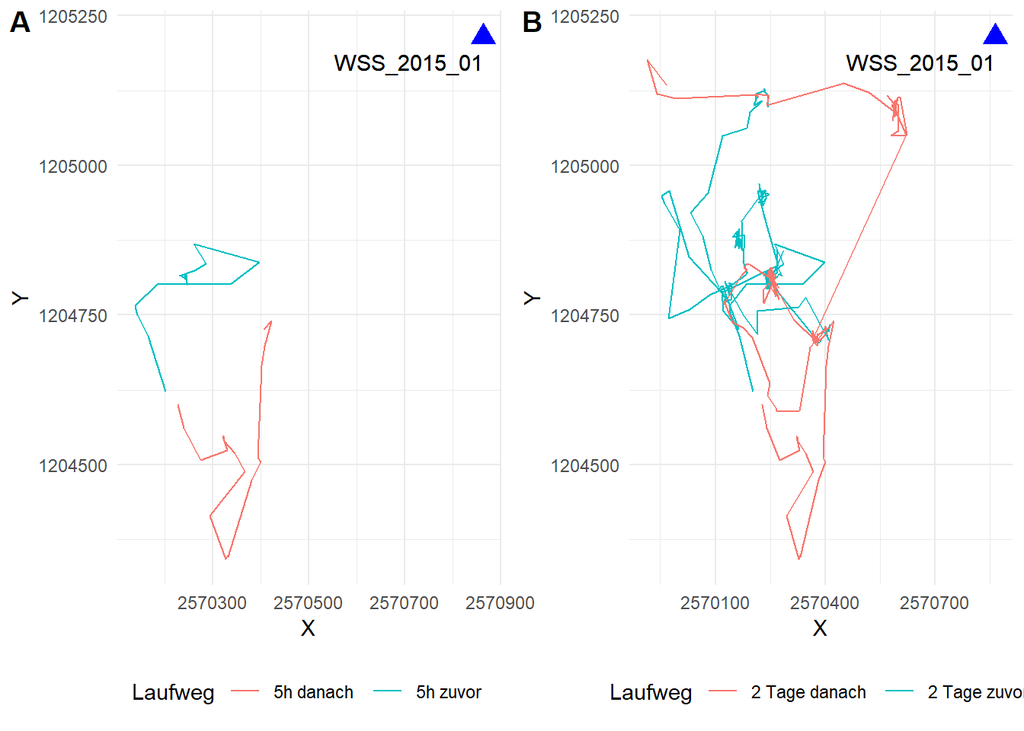

Auch hier ist kaum ein Einfluss des Wildschweinschrecks auf das Wildschwein zu erkennen. Dies bei einer Distanz zum Wildschweinschreck zu Zeitpunkt t2 von 884 Meter. Das Tier geht zwar kurzfristig etwas weiter weg, kommt dann aber zurück und hält sich sogar noch näher beim Schreck auf, als davor.

```r
Sabine_t2_t3_01_2d$distance_2015_01[1]
```

```
## [1] 884.4684
```

Nun wird noch der dritte Wildschweinschreck, der einen Einlfluss auf Sabine haben könnte, untersucht. Dies ist Wildschweinschreck *2015_03*. Es zeigt sich gleich am Anfang, dass die Distanz hier zu gross wäre. Zum Zeitpunkt t2 liegt die Distanz zum Schreck bei über 2000 Meter:

```r
Sabine_t2_t3_03_2d$distance_2015_03[1]
```

```
## [1] 2098.114
```

### Untersuchung Franz

Bei Franz und dem Wildschwienschreck 2015_01 sieht es ähnlich aus, die Distanz liegt zum Zeitpunkt vom Ertönen des ersten Schrecksignals bei 1678 Meter zum Schreck. Entsprechend wird auf Laufanalyse im Zusammenhang mit diesem Schreck verzichtet. Die Distanz ist sehr lang.

```r
Franz_t2_t3_01_2d$distance_2015_01[1]
```

```
## [1] 1677.762
```

### Untersuchung Olga

Zum Schluss wird noch Olga und ihre Reaktion auf den potenziell beeinflussbaren Wildschweinschreck *2015_01* untersucht. Hier wird erst einmal nur der Plot gezeigt, wo sich Olga fünf Stunden vor und nach dem ersten Alarmton befindet. Auch Sie scheint noch näher heranzugehen:

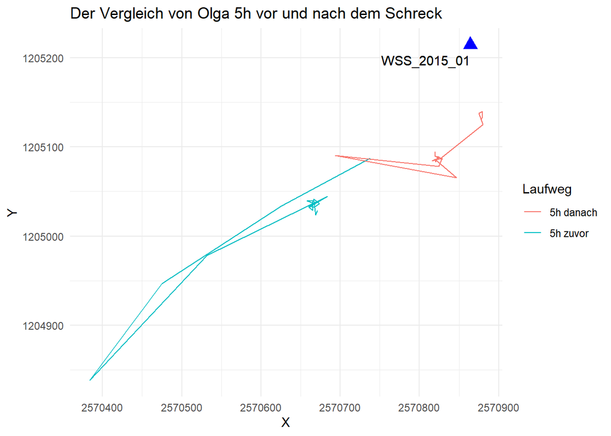

Olga befindet sich zum Zeitpunkt des ersten Alarmtons (t2) 128 Meter entfernt vom Schreck, wo gemäss ZHAW Studie der Imissionswert von 55dB noch zu 90% überschritten wird.

```r
Olga_t2_t3_01_2d$distance_2015_01[1]
```

```
## [1] 128.175
```

Für Olga wird nachfolgend die Laufbahn bei Nacht untersucht, da die Wildschweine eher zu Nacht in die Felder gehen. Zudem wird anhand von ausgewählten Zeitpunkten aufgezeigt, dass Olga nach dem Alarm sogar noch näher ran geht. Dabei ist der rote Punkt der Olga-Ort zum Wildschweinschreck-Start (t2) und Grün der Olga-Ort irgendwann in der Nacht.

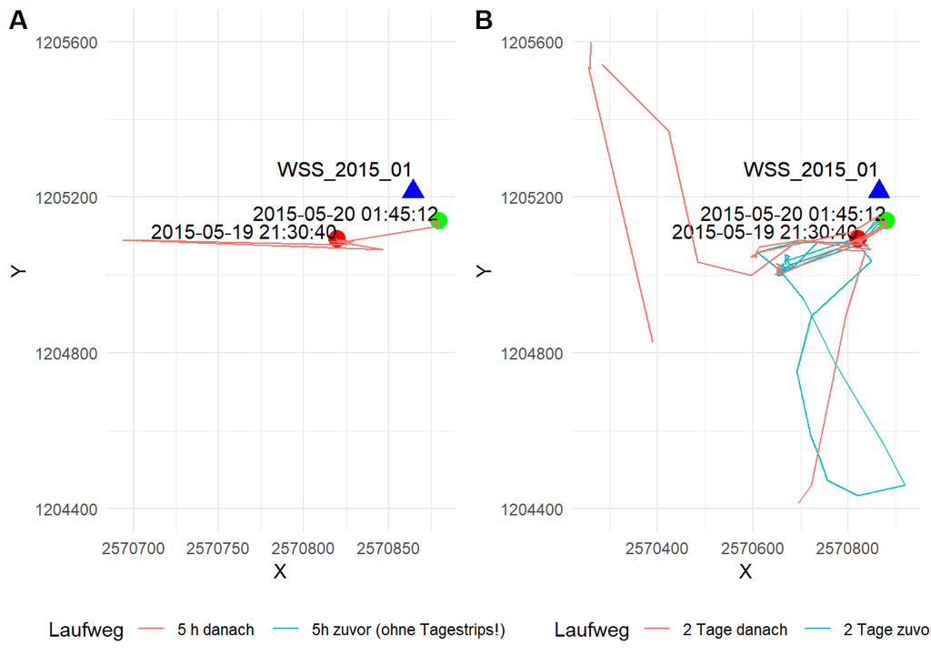

Wiederum ist kein Einfluss zu erkennen, der darauf hindeutet, dass das Wildschwein Olga sich vom Schreck abschrecken lässt. Olga geht sogar noch bis auf 76 Meter an den Wildschweinschreck ran, und das zu einem Zeitpunkt wo er angeschaltet ist:

```r
Olga_t2_t3_01_2d_nacht$distance_2015_01[1]
```

```
## [1] 128.175
```

```r
Olga_t2_t3_01_2d_nacht$distance_2015_01[18]
```

```
## [1] 76.28109
```

### Fazit Forschungsfrage 1

Vielleicht haben die Umweltbedingungen einen höheren Einfluss auf die Schweine als die alleinige Untersuchung des Schrecksignal-Einflusses. Dies wird mit der zweiten Forschungsfrage untersucht.

## Teil 3: Forschungsfrage 2, First Order Effects

> Wie entwickelt sich die räumlich-zeitliche Verteilung der Wildschweine vor und während der Testphase mit dem Schreck?

Die zweite Forschungsfrage wird entsprechend der Ergebnissen aus der ersten Forschungsfrage leicht angepasst. Anstelle zu untersuchen, wie sich die Wildschweinverteilung über die Zeit bis nach der Testphase entwickelt, wird wiederum nur auf zwei Zeitspannen (vor und nach dem ersten Alarm, Δt1 und Δt2) fokussiert. Ausserdem werden nur die zwei Wildschweine Sabine und Olga mit Wildschweinschreck *2015_01* untersucht, für die anderen Kombinationen eine zu unrealistische Distanz für eine Vergrähmung errechnet wurde.

In der Forschungsfrage 1 konnte keinen Einfluss der Wildschweinschrecks auf die Wildschweine nachgewiesen werden. Es könnte jedoch sein, dass der Einbezug von First Order Effects dieses Bild ändert (Gudmundsson et al., 2012). Es könnte ja sein, dass die Wildschweine beispielsweise in der Nähe des Schrecks bleiben, sie sich jedoch mehr im Wald aufhalten als davor. Dem wird mit Forschungsfrage 2 nachgegangen, indem für Sabine und Olga die Aufenthaltsorte bestimmt werden.

Als erstes werden die Aufenthaltsorte der Schweine nochmals geplottet, diesmal inklusive weiteren Informationen zu der Umgebung. Unterschiedliche Umrissfarben entsprechen dabei unterschiedichen Umgebungsmerkmalen.

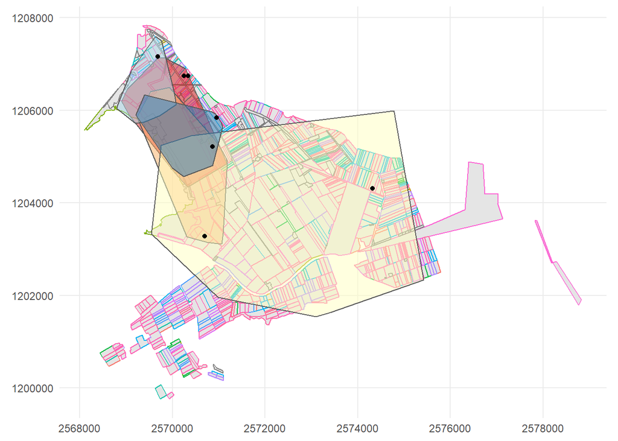

Zusätzlich wird noch eine Hintergurnd-Map und die Legende ergänzt, sodass die Grundlage noch besser verständlich ist.

[figure not shown]

Jetzt werden die Aufenthaltsorte der Wildschweine mit den Umgebungsdaten verknüpft. Danach wird berechnet, zu welchem Anteil sich Sabine und Olga in welcher Umgebung aufhalten. Dies wird für sieben Tage vor und sieben Tage nach dem ersten Schrecksignal untersucht. Man hätte hier auch 2 Tage ananlysieren können, um mit Forschungsfrage 1 Vergleiche anstellen zu können. Hier interessiert uns jedoch generell, ob die Schweine sich auf den Feldern aufhalten. Deshalb wird die Zeitspanne (Δt1 und Δt2) hier auf sieben Tage erhöht.

Der erste Plot zeigt die Aufenthaltsorte der beiden Wildschweine sieben Tage vor dem ersten Signalton (Δt1):

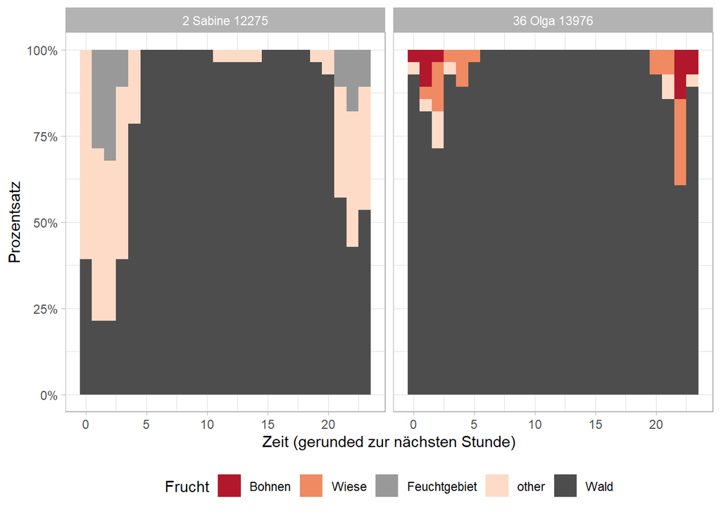

Der erste Plot zeigt die Aufenthaltsorte der beiden Wildschweine sieben Tage nach dem ersten Signalton (Δt2):

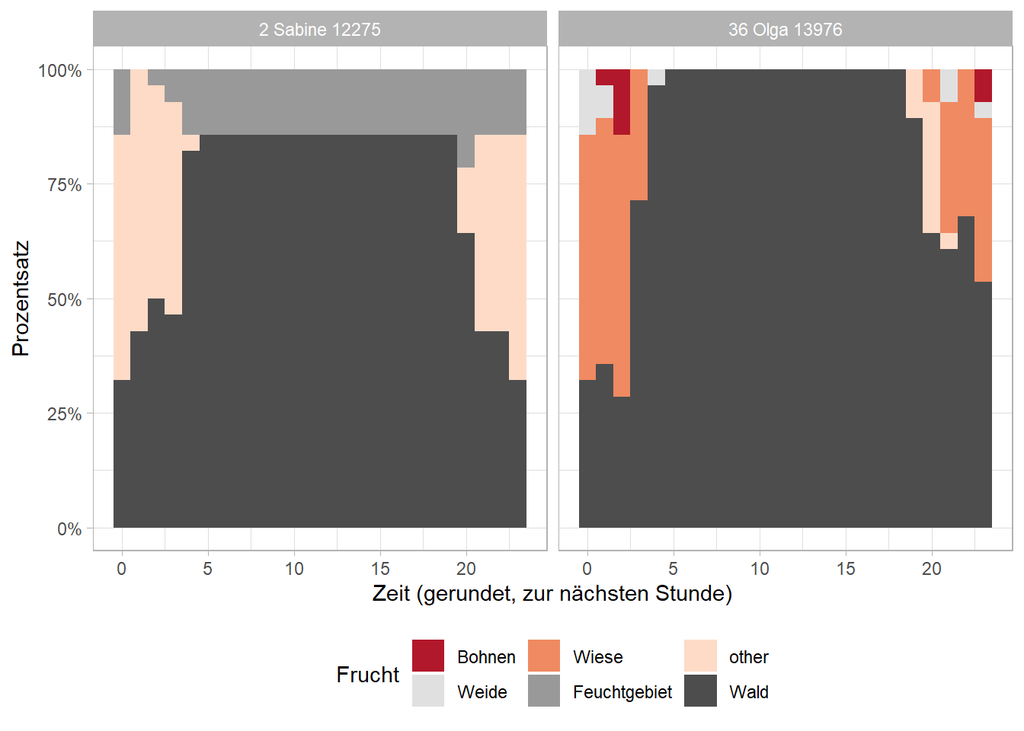

Für Sabine hat sich gezeigt, dass Sie sich sowieso im Wald und Feuchtgebiet aufgehalten hat und nicht auf die Felder ging. Entsprechend hat sie sich dort wohl nicht bedroht gefühlt. Sie ist auch nach dem der Schreck eingeschaltet wurde nicht auf die Felder gegangen. Es lässt sich nicht sagen, ob sie ohne den Wildschweinschreck auf das Feld gegangen wäre. Aus den Ergebnissen der Forschungsfrage 1 wissen wir, dass sie sich zum Zeitpunkt der Einschaltung des Wildschweinschrecks recht weit davon entfernt aufgehalten hat.

Es kann hier noch geprüft werden, wo denn der potenziell beeinflussende Wildschweinschreck steht:

```r
WSS_2015_01_crop <-  st_join(WSS_2015_01, crop_fanel)
WSS_2015_01_crop$Frucht
```

```
## [1] "Bohnen"
```

Der Wildschweinschreck steht in den Bohnen. Olga ist trotzdem noch in die Bohnen geganen, wenn auch vermeintlich etwas weniger. Ob dies signifikant wengier ist, lässt sich explorativ nicht beantworten und könnte in einer Nachfolgeuntersuchung genauer studiert werden.

### Fazit Forschungsfrage 2

Auch für Forschungsfrage 2 konnte mit der vorliegenden Untersuchung keine klare Beeinflussung der Wildschweinschrecks auf die Wildschweine festgestellt werden. Es hat sich gezeigt, dass Sabine vor und nach dem ersten Schreckalarm von Schreck 2015_01 wohl nie auf dem Feld war (NA’s vorbehalten). Bei Olga konnte keine klare Veränderung ihres Verhaltens festgestellt werden, sie schien sogar weiterhin auf das Bohnenfeld zu gehen - trotz Schreck.

## Diskussion

Leider konnte für die vorliegenden Daten keine Beeinflussung der Wildschweinschrecks auf die ausgewählten Wilschweine festgestellt werden. Auch ein klarer Effektbereich in Meter konnte anhand dieser Studie nicht definiert werden. Gründe für die unerwartete Reaktion können sehr vielschichtig sein. Vielleicht kannten die Wildschweine die Schrecks aus anderen Jahren (z.B.2014) schon oder das Signal wurde zu stark durch allfällige Barrieren wie Bäume oder hohe Plfanzen reduziert.

Zudem sollte analysiert werden, ob Wildschweinschreck-Richtung und Lautstärke einen Einfluss auf den Effektbereich haben. Ebenfalls wäre zu analyiseren, inwiefern sich die Wildschweine an den Schreck gewöhnen (Δt3 und Δt4). Das musste hier leider vernachlässigt werden, da keine klaren Resultate den Einfluss des Schrecks belegten. Die fist Order Effects könnte man anhand statistischer Methoden weiter untersuchen um beispielsweise zu ergründen, ob die Unterschiede der Aufenthaltsorte siginifkant sind. Bei einem Ähnlichen Aufbau von weiterführenden Studien, könnte ausserdem anstatt die Minimaldistanz pro Schwein und Schreck auch eingangs schon die Minimaldistanz pro Schwein und Schreck zum Zeitpunkt des jeweiligen ersten Alarms errechnet werden. So könnte man sich einige Plots von Anfang an ersparen.

## Bibliographie

Suter, Stefan, Sandro Stoller, und Benjamin Sigrist. „Prävention von Wildschweinschäden in der Landwirtschaft und Management von Wildschweinen in Schutzgebieten“, 31. Januar 2018. https://www.zhaw.ch/storage/hochschule/medien/news/

Gudmundsson, Joachim, Patrick Laube, und Thomas Wolle. „Computational Movement Analysis“, 2012, 26.

Wassmer, Alice. „Wildschweinschadensprävention im Landwirtschaftsgebiet“, 31. März 2017. https://moodle0.zhaw.ch/pluginfile.php/2648822/mod_resource/content/1/Masterarbeit_A.Wassmer.pdf.